# San Joaquin River

Sadie Gill, Mark Tompkins, Erin Cain

June 24, 2019

## Future Data Improvements

None Planned

## Instream Spawning and Rearing Habiat

**Data Source:**  
[Final Lower Tuolumne Instream Flow Study Report](https://s3-us-west-2.amazonaws.com/cvpiahabitat-r-package/cvpia-sit-model-inputs/Stillwater2010_Tuolumne_P-2299-075_71_DP_FLA_AttC_StudyRept_IFIM_AppA-H_140428.pdf) (pg. 108-109)  
[Stanislaus Aceituno 1993](https://cvpiahabitat-r-package.s3-us-west-2.amazonaws.com/cvpia-sit-model-inputs/Aceituno1993_StanislausRiverIFIMStudy.pdf) (pg 19)  
[Stanislaus FWS 2012](https://cvpiahabitat-r-package.s3-us-west-2.amazonaws.com/cvpia-sit-model-inputs/CVPIA_Annual_Progress_Report_Fiscal_Year_2012.pdf) (pg 6)  
[Merced ID 2013](https://cvpiahabitat-r-package.s3-us-west-2.amazonaws.com/cvpia-sit-model-inputs/MID2013_MercedIFIMStudy.pdf) (pg 67-75)

No watershed specific salmonid habitat data was available for the San Joaquin River. A regional weighted usable area (WUA) relationship with flow was derived for the San Joaquin River by averaging the WUA values on the three tributaries of the San Joaquin. Spawning and rearing data from the Merced, Stanislaus, and Tuolumne Rivers were used to estimate spawning and rearing WUA for the San Joaquin. The data for these three tributaries was provided by Mark Gard from the U.S. Fish and Wildlife Service in a spreadsheet (see ‘~/cvpiaHabitat/data-raw/mark_gard_data/IFIMWUA.xlsx’). Mark Gard instructed us to use A18:E48 of the ‘Merced’ tab, I4:N60 of the ‘Stanislaus’ tab, and A2:H32 in the ‘Tuolumne’ tab within his ‘IFIMWUA.xlsx’ spreadsheet.

### Combine Spawning and Rearing Data

The instream spawning and rearing habitat data described above for Fall Run Chinook Salmon (FR) and is combined for use in the DSM in the following format. Units are in square feet per 1000 feet.

| flow_cfs | FR_fry_wua | FR_juv_wua | FR_spawn_wua | watershed |
| --- | --- | --- | --- | --- |
| 25 | 21336.02 | 28359.27 | 3064.559 | San Joaquin River |
| 50 | 21336.02 | 28359.27 | 3289.612 | San Joaquin River |
| 100 | 19509.70 | 29605.21 | 6481.759 | San Joaquin River |
| 150 | 17522.17 | 29752.65 | 9668.076 | San Joaquin River |
| 200 | 16077.04 | 28765.61 | 11340.041 | San Joaquin River |

*…with 42 more rows.*

### Spawning WUA

The instream spawning habitat weighted usable areas for Fall Run Chinook Salmon in the San Joaquin River.

#### Chinook Salmon Spawning WUA Plot

The following plot shows the weighted usable spawning area in square feet per thousand feet of river for Fall Run Chinook Salmon. These area per length rates are multiplied by the total spawning reach length mapped by the SIT.

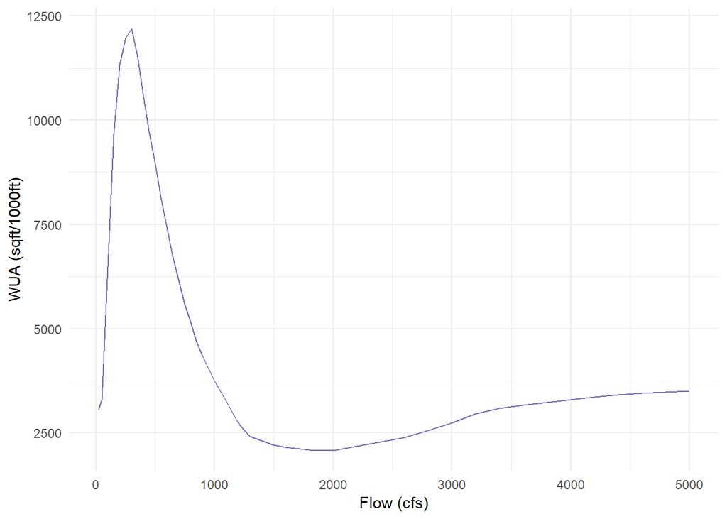

### Rearing WUA

The fry and juvenile instream rearing habitat weighted usable areas for Fall Run Chinook Salmon in the San Joaquin River.

#### Rearing WUA Plot

The following plot shows the weighted usable rearing area in square feet per thousand feet of river for Fall Run Chinook Salmon fry and juvenile. These rates are multiplied by the total rearing reach length mapped by the SIT.

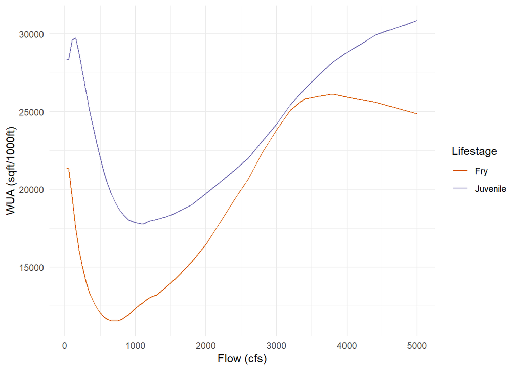